# EasyVisa Project

## Context:

Business communities in the United States are facing high demand for human resources, but one of the constant challenges is identifying and attracting the right talent, which is perhaps the most important element in remaining competitive. Companies in the United States look for hard-working, talented, and qualified individuals both locally as well as abroad.

The Immigration and Nationality Act (INA) of the US permits foreign workers to come to the United States to work on either a temporary or permanent basis. The act also protects US workers against adverse impacts on their wages or working conditions by ensuring US employers' compliance with statutory requirements when they hire foreign workers to fill workforce shortages. The immigration programs are administered by the Office of Foreign Labor Certification (OFLC).

OFLC processes job certification applications for employers seeking to bring foreign workers into the United States and grants certifications in those cases where employers can demonstrate that there are not sufficient US workers available to perform the work at wages that meet or exceed the wage paid for the occupation in the area of intended employment.

## Objective:

In FY 2016, the OFLC processed 775,979 employer applications for 1,699,957 positions for temporary and permanent labor certifications. This was a nine percent increase in the overall number of processed applications from the previous year. The process of reviewing every case is becoming a tedious task as the number of applicants is increasing every year.

The increasing number of applicants every year calls for a Machine Learning based solution that can help in shortlisting the candidates having higher chances of VISA approval. OFLC has hired your firm EasyVisa for data-driven solutions. You as a data scientist have to analyze the data provided and, with the help of a classification model:

- Facilitate the process of visa approvals.
- Recommend a suitable profile for the applicants for whom the visa should be certified or denied based on the drivers that significantly influence the case status.

## Data Description

The data contains the different attributes of the employee and the employer. The detailed data dictionary is given below.

- case_id: ID of each visa application
- continent: Information of continent the employee
- education_of_employee: Information of education of the employee
- has_job_experience: Does the employee has any job experience? Y= Yes; N = No
- requires_job_training: Does the employee require any job training? Y = Yes; N = No
- no_of_employees: Number of employees in the employer's company
- yr_of_estab: Year in which the employer's company was established
- region_of_employment: Information of foreign worker's intended region of employment in the US.
- prevailing_wage: Average wage paid to similarly employed workers in a specific occupation in the area of intended employment. The purpose of the prevailing wage is to ensure that the foreign worker is not underpaid compared to other workers offering the same or similar service in the same area of employment.
- unit_of_wage: Unit of prevailing wage. Values include Hourly, Weekly, Monthly, and Yearly.
- full_time_position: Is the position of work full-time? Y = Full Time Position; N = Part Time Position
- case_status: Flag indicating if the Visa was certified or denied

## Importing necessary libraries and data

```python
# Importing appropriate libraries

# For filtering out any warnings
import warnings
warnings.filterwarnings('ignore')

# For loading data and data processing
import numpy as np
import pandas as pd

# For visualizations
import matplotlib.pyplot as plt
import seaborn as sns

# For splitting data into train and test sets
from sklearn.model_selection import train_test_split

# For importing decision tree classifier and different ensemble classifiers
from sklearn.ensemble import BaggingClassifier
from sklearn.ensemble import RandomForestClassifier
from sklearn.ensemble import StackingClassifier
from sklearn.tree import DecisionTreeClassifier
from sklearn import tree

# For importing boosting algorithms
from sklearn.ensemble import AdaBoostClassifier, GradientBoostingClassifier
from xgboost import XGBClassifier

# For model tuning and getting different metric scores
from sklearn import metrics
from sklearn.metrics import confusion_matrix, classification_report, accuracy_score, precision_score, recall_score,f1_score,roc_auc_score
from sklearn.model_selection import GridSearchCV
```

## Data Overview

- Observations
- Sanity checks

```python
# Loading EasyVisa.csv into a datframe
df = pd.read_csv("EasyVisa.csv")
df
```

|  | case_id | continent | education_of_employee | has_job_experience | requires_job_training | no_of_employees | yr_of_estab | region_of_employment | prevailing_wage | unit_of_wage | full_time_position | case_status |
| --- | --- | --- | --- | --- | --- | --- | --- | --- | --- | --- | --- | --- |
| 0 | EZYV01 | Asia | High School | N | N | 14513 | 2007 | West | 592.2029 | Hour | Y | Denied |
| 1 | EZYV02 | Asia | Master's | Y | N | 2412 | 2002 | Northeast | 83425.6500 | Year | Y | Certified |
| 2 | EZYV03 | Asia | Bachelor's | N | Y | 44444 | 2008 | West | 122996.8600 | Year | Y | Denied |
| 3 | EZYV04 | Asia | Bachelor's | N | N | 98 | 1897 | West | 83434.0300 | Year | Y | Denied |
| 4 | EZYV05 | Africa | Master's | Y | N | 1082 | 2005 | South | 149907.3900 | Year | Y | Certified |
| ... | ... | ... | ... | ... | ... | ... | ... | ... | ... | ... | ... | ... |
| 25475 | EZYV25476 | Asia | Bachelor's | Y | Y | 2601 | 2008 | South | 77092.5700 | Year | Y | Certified |
| 25476 | EZYV25477 | Asia | High School | Y | N | 3274 | 2006 | Northeast | 279174.7900 | Year | Y | Certified |
| 25477 | EZYV25478 | Asia | Master's | Y | N | 1121 | 1910 | South | 146298.8500 | Year | N | Certified |
| 25478 | EZYV25479 | Asia | Master's | Y | Y | 1918 | 1887 | West | 86154.7700 | Year | Y | Certified |
| 25479 | EZYV25480 | Asia | Bachelor's | Y | N | 3195 | 1960 | Midwest | 70876.9100 | Year | Y | Certified |

25480 rows × 12 columns

```python
# Viewing first five rows
df.head()
```

|  | case_id | continent | education_of_employee | has_job_experience | requires_job_training | no_of_employees | yr_of_estab | region_of_employment | prevailing_wage | unit_of_wage | full_time_position | case_status |
| --- | --- | --- | --- | --- | --- | --- | --- | --- | --- | --- | --- | --- |
| 0 | EZYV01 | Asia | High School | N | N | 14513 | 2007 | West | 592.2029 | Hour | Y | Denied |
| 1 | EZYV02 | Asia | Master's | Y | N | 2412 | 2002 | Northeast | 83425.6500 | Year | Y | Certified |
| 2 | EZYV03 | Asia | Bachelor's | N | Y | 44444 | 2008 | West | 122996.8600 | Year | Y | Denied |
| 3 | EZYV04 | Asia | Bachelor's | N | N | 98 | 1897 | West | 83434.0300 | Year | Y | Denied |
| 4 | EZYV05 | Africa | Master's | Y | N | 1082 | 2005 | South | 149907.3900 | Year | Y | Certified |

```python
# Viewing a sample of the data
df.sample(10)
```

|  | case_id | continent | education_of_employee | has_job_experience | requires_job_training | no_of_employees | yr_of_estab | region_of_employment | prevailing_wage | unit_of_wage | full_time_position | case_status |
| --- | --- | --- | --- | --- | --- | --- | --- | --- | --- | --- | --- | --- |
| 7406 | EZYV7407 | Asia | Doctorate | N | N | 306 | 1991 | Northeast | 91225.1900 | Year | Y | Certified |
| 14858 | EZYV14859 | North America | Master's | Y | N | 5146 | 1994 | West | 23929.4100 | Year | Y | Certified |
| 9552 | EZYV9553 | Asia | Master's | N | N | 2556 | 2004 | Midwest | 92629.2800 | Year | Y | Certified |
| 3068 | EZYV3069 | North America | Doctorate | Y | N | 5395 | 1999 | West | 11633.8500 | Year | Y | Certified |
| 20213 | EZYV20214 | Asia | High School | N | N | 5203 | 2001 | South | 792.1299 | Hour | Y | Certified |
| 2959 | EZYV2960 | Asia | Master's | Y | N | 75 | 2002 | Northeast | 78606.6500 | Year | Y | Certified |
| 304 | EZYV305 | Asia | Bachelor's | Y | N | 2114 | 1977 | West | 596.2488 | Hour | Y | Certified |
| 12576 | EZYV12577 | Asia | Bachelor's | N | N | 3881 | 1853 | Midwest | 50072.2900 | Year | Y | Certified |
| 140 | EZYV141 | Asia | Master's | N | N | 4390 | 1944 | South | 88720.2900 | Year | N | Certified |
| 17836 | EZYV17837 | Asia | Master's | Y | N | 447 | 2004 | South | 56467.6100 | Year | Y | Certified |

```python
# Shape of the dataframe
print(f"The shape of the dataframe is {df.shape}. \nThere are {df.shape[0]} rows and {df.shape[1]} columns")
```

```
The shape of the dataframe is (25480, 12).
There are 25480 rows and 12 columns
```

```python
# Datatypes in dataframe
print(df.dtypes)
```

```
case_id                   object
continent                 object
education_of_employee     object
has_job_experience        object
requires_job_training     object
no_of_employees            int64
yr_of_estab                int64
region_of_employment      object
prevailing_wage          float64
unit_of_wage              object
full_time_position        object
case_status               object
dtype: object
```

```python
# Making a copy of the original dataframe to preserve the original data
df1 = df.copy()
```

```python
# Converting case_id, continent, education_of_employee, has_job_experience, requires_job_training, region_of_employment, unit_of_wage, full_time_position, case_status to categorical type from object type
cols = ["case_id", "continent", "education_of_employee", "has_job_experience", "requires_job_training", "region_of_employment", "unit_of_wage", "full_time_position", "case_status"]
df1[cols] = df1[cols].astype("category")
```

```python
# Confirming that datatype convesion was successful and there are no more object datatypes
print(df1.dtypes)
```

```
case_id                  category
continent                category
education_of_employee    category
has_job_experience       category
requires_job_training    category
no_of_employees             int64
yr_of_estab                 int64
region_of_employment     category
prevailing_wage           float64
unit_of_wage             category
full_time_position       category
case_status              category
dtype: object
```

```python
# Determining if there are any missing values in the dataframe
# Total missing values for each column sorted in descending order
print(df1.isnull().sum().sort_values(ascending=False))
```

```
case_id                  0
continent                0
education_of_employee    0
has_job_experience       0
requires_job_training    0
no_of_employees          0
yr_of_estab              0
region_of_employment     0
prevailing_wage          0
unit_of_wage             0
full_time_position       0
case_status              0
dtype: int64
```

```python
# Any missing values?
print("True or False, are there any missing values?", df1.isnull().values.any())
```

```
True or False, are there any missing values? False
```

```python
# Total number of missing values (if any)
print("Total number of missing values (if any) is", df1.isnull().sum().sum())
```

```
Total number of missing values (if any) is 0
```

```python
# Number of unique values in each column sorted in descending order
print(df1.nunique().sort_values(ascending=False))
```

```
case_id                  25480
prevailing_wage          25454
no_of_employees           7105
yr_of_estab                199
continent                    6
region_of_employment         5
education_of_employee        4
unit_of_wage                 4
has_job_experience           2
requires_job_training        2
full_time_position           2
case_status                  2
dtype: int64
```

## Exploratory Data Analysis (EDA)

- EDA is an important part of any project involving data.
- It is important to investigate and understand the data better before building a model with it.
- A few questions have been mentioned below which will help you approach the analysis in the right manner and generate insights from the data.
- A thorough analysis of the data, in addition to the questions mentioned below, should be done.

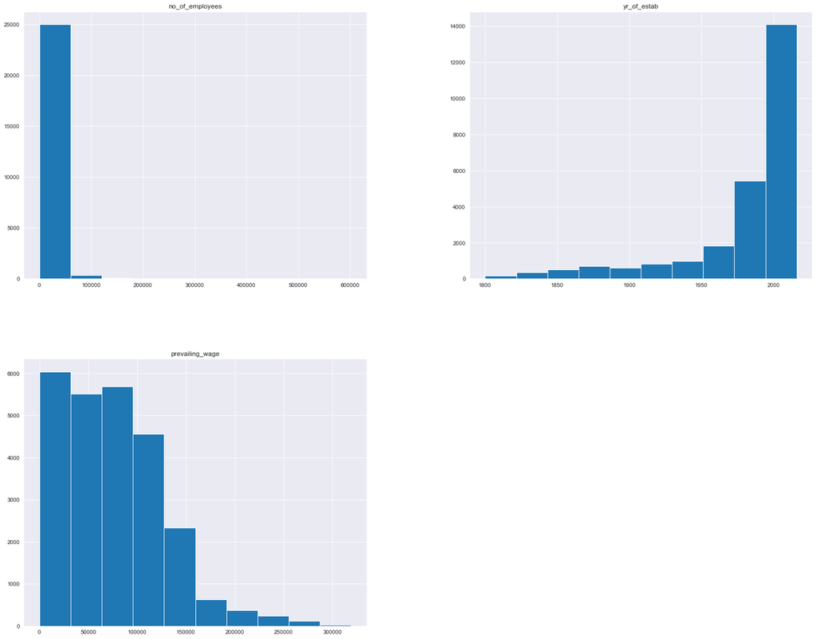

```python
# Distribution of numerical variables
sns.set_style("darkgrid")
df1.hist(figsize = (25, 20))
plt.show()
```

```python
# Statistical summary of all data
df1.describe(include = 'all').T
```

|  | count | unique | top | freq | mean | std | min | 25% | 50% | 75% | max |
| --- | --- | --- | --- | --- | --- | --- | --- | --- | --- | --- | --- |
| case_id | 25480 | 25480 | EZYV01 | 1 | NaN | NaN | NaN | NaN | NaN | NaN | NaN |
| continent | 25480 | 6 | Asia | 16861 | NaN | NaN | NaN | NaN | NaN | NaN | NaN |
| education_of_employee | 25480 | 4 | Bachelor's | 10234 | NaN | NaN | NaN | NaN | NaN | NaN | NaN |
| has_job_experience | 25480 | 2 | Y | 14802 | NaN | NaN | NaN | NaN | NaN | NaN | NaN |
| requires_job_training | 25480 | 2 | N | 22525 | NaN | NaN | NaN | NaN | NaN | NaN | NaN |
| no_of_employees | 25480.0 | NaN | NaN | NaN | 5667.04321 | 22877.928848 | -26.0 | 1022.0 | 2109.0 | 3504.0 | 602069.0 |
| yr_of_estab | 25480.0 | NaN | NaN | NaN | 1979.409929 | 42.366929 | 1800.0 | 1976.0 | 1997.0 | 2005.0 | 2016.0 |
| region_of_employment | 25480 | 5 | Northeast | 7195 | NaN | NaN | NaN | NaN | NaN | NaN | NaN |
| prevailing_wage | 25480.0 | NaN | NaN | NaN | 74455.814592 | 52815.942327 | 2.1367 | 34015.48 | 70308.21 | 107735.5125 | 319210.27 |
| unit_of_wage | 25480 | 4 | Year | 22962 | NaN | NaN | NaN | NaN | NaN | NaN | NaN |
| full_time_position | 25480 | 2 | Y | 22773 | NaN | NaN | NaN | NaN | NaN | NaN | NaN |
| case_status | 25480 | 2 | Certified | 17018 | NaN | NaN | NaN | NaN | NaN | NaN | NaN |

### Observations for the statistical summary table

- No of employees for a company applying for visas has an average of 5,667 employees. The minimum number of employees is -26 and maximum number of employees is 602,069.
- The median number of employees at a company applying for visas is 2109.
- No of employees appears to have data entry errors as employees of a company can't be negative. There might be more companies that have negative values. This will need to be addressed before modeling.
- The average year of establishment for a company applying for visas is 1979. The oldest company applying for visas was established in 1800. The youngest company applying for visas was established in 2016.
- The median year of establishment for companies applying for visas is 1997.
- The average prevailing wage of the companies applying for a visa is \$74,455.81. The miniminum prevailing wage is \\$2.14 (this sounds too low and might be a data entry error) and the maximum prevailing wage is \$319,210.27.
- The median prevailing wage of the companies applying for a visa is \$70,308.21

```python
# function to plot a boxplot and a histogram along the same scale.

def histogram_boxplot(data, feature, figsize=(12, 7), kde=False, bins=None):
    """
    Boxplot and histogram combined

    data: dataframe
    feature: dataframe column
    figsize: size of figure (default (12,7))
    kde: whether to the show density curve (default False)
    bins: number of bins for histogram (default None)
    """
    f2, (ax_box2, ax_hist2) = plt.subplots(
        nrows=2,  # Number of rows of the subplot grid= 2
        sharex=True,  # x-axis will be shared among all subplots
        gridspec_kw={"height_ratios": (0.25, 0.75)},
        figsize=figsize,
    )  # creating the 2 subplots
    sns.boxplot(
        data=data, x=feature, ax=ax_box2, showmeans=True, color="violet"
    )  # boxplot will be created and a star will indicate the mean value of the column
    sns.histplot(
        data=data, x=feature, kde=kde, ax=ax_hist2, bins=bins, palette="winter"
    ) if bins else sns.histplot(
        data=data, x=feature, kde=kde, ax=ax_hist2
    )  # For histogram
    ax_hist2.axvline(
        data[feature].mean(), color="green", linestyle="--"
    )  # Add mean to the histogram
    ax_hist2.axvline(
        data[feature].median(), color="black", linestyle="-"
    )  # Add median to the histogram
```

```python
# function to create labeled barplots

def labeled_barplot(data, feature, perc=False, n=None):
    """
    Barplot with percentage at the top

    data: dataframe
    feature: dataframe column
    perc: whether to display percentages instead of count (default is False)
    n: displays the top n category levels (default is None, i.e., display all levels)
    """

    total = len(data[feature])  # length of the column
    count = data[feature].nunique()
    if n is None:
        plt.figure(figsize=(count + 1, 5))
    else:
        plt.figure(figsize=(n + 1, 5))

    plt.xticks(rotation=90, fontsize=15)
    ax = sns.countplot(
        data=data,
        x=feature,
        palette="Paired",
        order=data[feature].value_counts().index[:n].sort_values(),
    )

    for p in ax.patches:
        if perc == True:
            label = "{:.1f}%".format(
                100 * p.get_height() / total
            )  # percentage of each class of the category
        else:
            label = p.get_height()  # count of each level of the category

        x = p.get_x() + p.get_width() / 2  # width of the plot
        y = p.get_height()  # height of the plot

        ax.annotate(
            label,
            (x, y),
            ha="center",
            va="center",
            size=12,
            xytext=(0, 5),
            textcoords="offset points",
        )  # annotate the percentage

    plt.show()  # show the plot
```

## Univariate Analysis

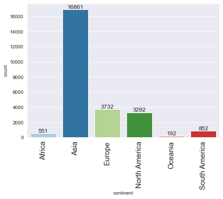

```python
# Continents visa applicants are from
labeled_barplot(df1, "continent")
```

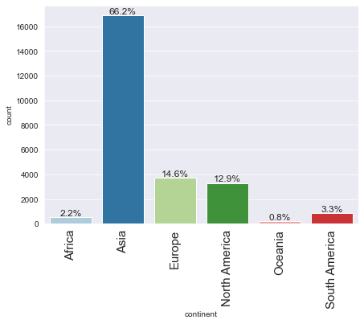

```python
# Continents visa applicants are from as a percentage
labeled_barplot(df1, "continent", perc = True)
```

### Observations for continent

- About two thirds (66.2%) of the visa employees come from Asia.
- After Asia, Europe (14.6%) and North America (12.9%) are in the second and third spots.
- Very little visa employees from South America, Africa, and Oceania.
- Imbalanced in favor of Continent - Asia.

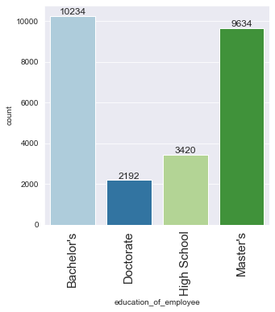

```python
# Education of the visa applicants are from
labeled_barplot(df1, "education_of_employee")
```

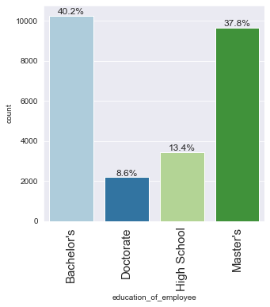

```python
# Education of the visa applicants are from as a percentage
labeled_barplot(df1, "education_of_employee", perc = True)
```

### Observations for education_of_employee

- The top two education levels of visa employees are Bachelor's (40.2%) and Master's (37.8%).
- Interesting to note that there are more visa employees with a high school education (13.4%) than a Doctorate (8.6%).

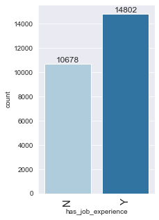

```python
# Job experience of the visa applicants
labeled_barplot(df1, "has_job_experience")
```

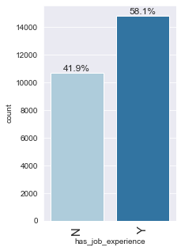

```python
# Job experience of the visa applicants as a percentage
labeled_barplot(df1, "has_job_experience", perc = True)
```

### Observations for has_job_experience

- For visa employees, most of them (58.1%) have job experience.
- 41.9% of visa employees didn't have job experience.
- Some imbalance in favor of Yes - has job experience.

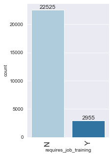

```python
# Knowledge of the visa applicants
labeled_barplot(df1, "requires_job_training")
```

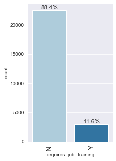

```python
# Knowledge of the visa applicants as a percentage
labeled_barplot(df1, "requires_job_training", perc = True)
```

```python
# number of employees of company applying for visa
# Since the values for number of employees is too many for a barplot, displaying values sorted in descending order
df1.no_of_employees.sort_values(ascending=False)
```

```
21339    602069
1345     594472
20345    581468
11317    579004
9587     547172
          ...
7318        -26
2918        -26
6634        -26
17983       -26
14146       -26
Name: no_of_employees, Length: 25480, dtype: int64
```

```python
df1.no_of_employees.min()
```

```
-26
```

```python
df1.no_of_employees.max()
```

```
602069
```

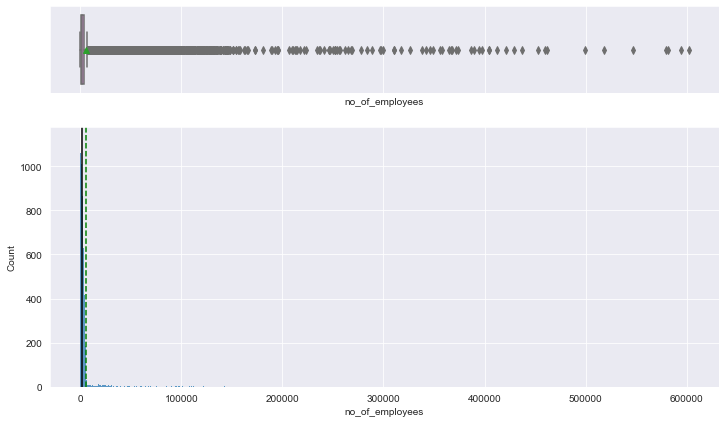

```python
# Number of employees at company applying for visa histogram and boxplot
histogram_boxplot(df1, "no_of_employees")
```

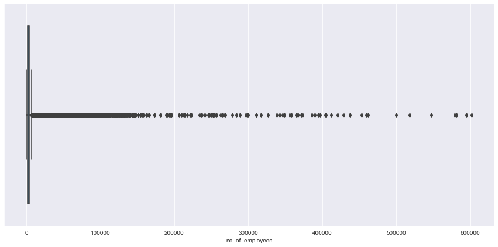

```python
# Number of employees at company applying for visa boxplot
plt.figure(figsize=(15, 7))
sns.boxplot(data = df1, x = "no_of_employees")
```

### Observations for no_of_employees

```python
# year company applying for visa was established
# Since the values for yr_of_estab is too many for a barplot, displaying value counts
df1.yr_of_estab.value_counts().sort_values(ascending=False)
```

```
1998    1134
2005    1051
2001    1017
2007     994
1999     870
        ...
1842       6
1846       4
1822       4
1810       3
1824       2
Name: yr_of_estab, Length: 199, dtype: int64
```

```python
# Since the values for yr_of_estab is too many for a barplot, displaying value counts as a percentage
df1.yr_of_estab.value_counts(normalize = True).sort_values(ascending=False) * 100
```

```
1998    4.450549
2005    4.124804
2001    3.991366
2007    3.901099
1999    3.414443
          ...
1842    0.023548
1846    0.015699
1822    0.015699
1810    0.011774
1824    0.007849
Name: yr_of_estab, Length: 199, dtype: float64
```

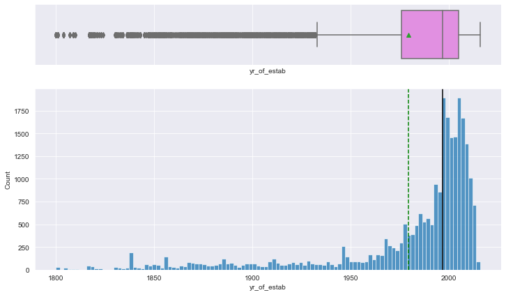

```python
# year company applying for visa was established histogram and boxplot
histogram_boxplot(df1, "yr_of_estab")
```

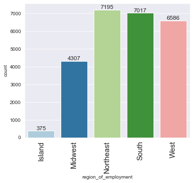

```python
# Region of employment for companies applying for visa
labeled_barplot(df1, "region_of_employment")
```

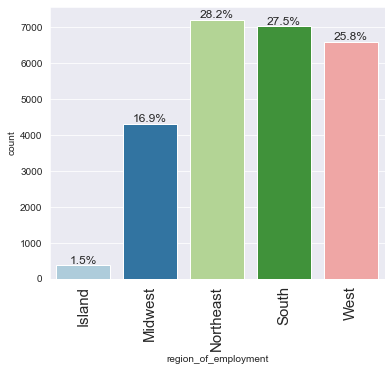

```python
# Region of employment for companies applying for visa as a percentage
labeled_barplot(df1, "region_of_employment", perc = True)
```

### Observations for region_of_employment

- Most of the companies applying for visas are based in the Northeast with 28.2% of applications coming from Northeast companies.
- Following the Northeast are companies based in the South and West with 27.5% and 25.8% respectively.
- The Northeast, South, and West regions are pretty close to each other. After them is a steep drop off with the Midwest (16.9%) and Island (1.5%).

```python
# prevailing wage for visa applicant
# Since the values for prevailing_wage is too many for a barplot,  displaying values sorted in descending order
df1.prevailing_wage.sort_values(ascending=False)
```

```
21077    319210.2700
14810    318446.0500
12215    315497.6000
16223    314156.0600
20957    311734.4900
            ...
5455          3.4889
634           3.3188
17448         3.0031
22855         2.9561
20575         2.1367
Name: prevailing_wage, Length: 25480, dtype: float64
```

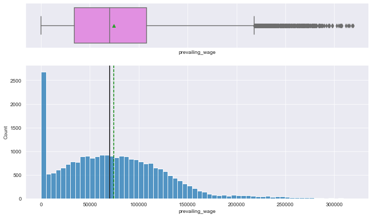

```python
# prevailing wage histogram and boxplot
histogram_boxplot(df1, "prevailing_wage")
```

### Observation for prevailing wage

- There are almost as many unique prevailing wages (25454) as there are visa applications (25480).
- The highest prevailing wage is \$319,210.27.
- The lowest prevailing wage is \$2.14, which might be an hourly wage. If it is an hourly wage, it is below the minimum wage of \\$7.25. This might be a data entry error.
- The mean is greater than the median, and to the right of the boxplot, there are many outliers.
- Looking at the histogram, a large number of prevailing wages in \$0 to \\$10,000 and then \$50,000 to \\$150,000, suggesting that the prevailing wages are being reported as hourly, monthly, yearly, or weekly.

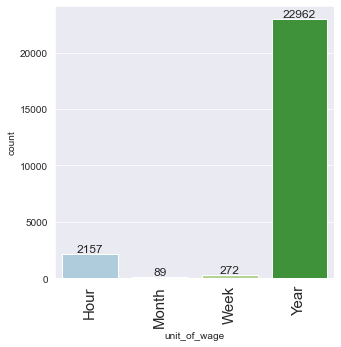

```python
# unit of wage for visa applicant
labeled_barplot(df1, "unit_of_wage")
```

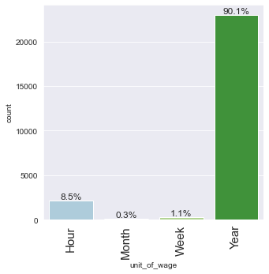

```python
# unit of wage for visa applicant as a percentage
labeled_barplot(df1, "unit_of_wage", perc = True)
```

### Observations for unit_of_wage

- A huge majority (90.1%) of companies applying for visas indicated the prevailing wage they put on the application is a yearly one.
- After yearly, the most common unit of pay used in applications is hourly (8.5%), weekly (1.1%), and monthly (0.3%).
- Highly imbalanced in favor of Unit of Wage - Year.

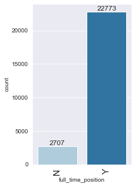

```python
# Employment status of role for visa applicant
labeled_barplot(df1, "full_time_position")
```

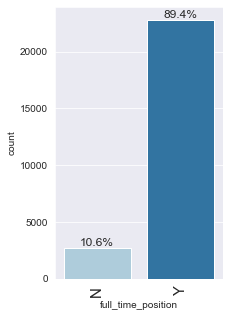

```python
# Employment status of role for visa applicant as a percentage
labeled_barplot(df1, "full_time_position", perc = True)
```

### Observations for full_time_position

- A huge majority (89.4%) of the companies applying for visas are looking to fill full time positions.
- Only 10.6% of visa applications were for part time roles.
- Highly imbalanced in favor of Yes - full time position.

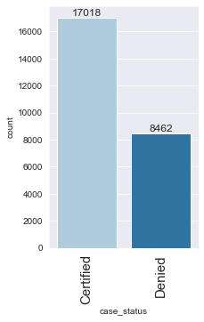

```python
# case status of visa applicant
labeled_barplot(df1, "case_status")
```

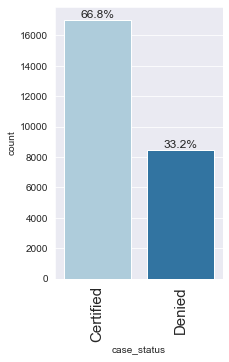

```python
# case status of visa applicant as a percentage
labeled_barplot(df1, "case_status", perc = True)
```

### Observations for case_status

- Just over two thirds (66.8%) of visa applications were certified.
- 33.2% off visa applications were denied.
- Highly imbalanced in favor of Visa status - Certified.

### Bivariate Analysis

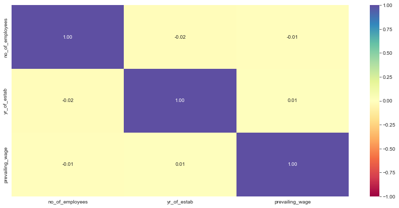

```python
# Correlation heatmap for all numerical variables
plt.figure(figsize=(15, 7))
sns.heatmap(df1.corr(), annot=True, vmin=-1, vmax=1, fmt=".2f", cmap="Spectral")
plt.show()
```

### Observation for correlation matrix

- None of the numeric features have any correlation with each other since the values are almost 0 for each of the correlations (excluding the correlations where the feature is correlated with itself).

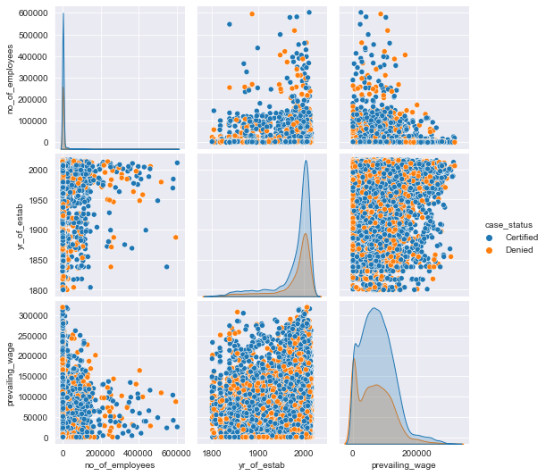

```python
# Pairplots with hue as case_status (the target variable)
sns.pairplot(df1, hue = "case_status")
plt.show()
```

```python
def stacked_barplot(data, predictor, target):
    """
    Print the category counts and plot a stacked bar chart

    data: dataframe
    predictor: independent variable
    target: target variable
    """
    count = data[predictor].nunique()
    sorter = data[target].value_counts().index[-1]
    tab1 = pd.crosstab(data[predictor], data[target], margins=True).sort_values(
        by=sorter, ascending=False
    )
    print(tab1)
    print("-" * 120)
    tab = pd.crosstab(data[predictor], data[target], normalize="index").sort_values(
        by=sorter, ascending=False
    )
    tab.plot(kind="bar", stacked=True, figsize=(count + 5, 5))
    plt.legend(
        loc="lower left", frameon=False,
    )
    plt.legend(loc="upper left", bbox_to_anchor=(1, 1))
    plt.show()
```

```python
### function to plot distributions wrt target

def distribution_plot_wrt_target(data, predictor, target):

    fig, axs = plt.subplots(2, 2, figsize=(12, 10))

    target_uniq = data[target].unique()

    axs[0, 0].set_title("Distribution of target for target=" + str(target_uniq[0]))
    sns.histplot(
        data=data[data[target] == target_uniq[0]],
        x=predictor,
        kde=True,
        ax=axs[0, 0],
        color="teal",
        stat="density",
    )

    axs[0, 1].set_title("Distribution of target for target=" + str(target_uniq[1]))
    sns.histplot(
        data=data[data[target] == target_uniq[1]],
        x=predictor,
        kde=True,
        ax=axs[0, 1],
        color="orange",
        stat="density",
    )

    axs[1, 0].set_title("Boxplot w.r.t target")
    sns.boxplot(data=data, x=target, y=predictor, ax=axs[1, 0], palette="gist_rainbow")

    axs[1, 1].set_title("Boxplot (without outliers) w.r.t target")
    sns.boxplot(
        data=data,
        x=target,
        y=predictor,
        ax=axs[1, 1],
        showfliers=False,
        palette="gist_rainbow",
    )

    plt.tight_layout()
    plt.show()
```

### Looking at relationships with target variable, "case_status"

```
case_status    Certified  Denied    All
continent
All                17018    8462  25480
Asia               11012    5849  16861
North America       2037    1255   3292
Europe              2957     775   3732
South America        493     359    852
Africa               397     154    551
Oceania              122      70    192
------------------------------------------------------------------------------------------------------------------------
```

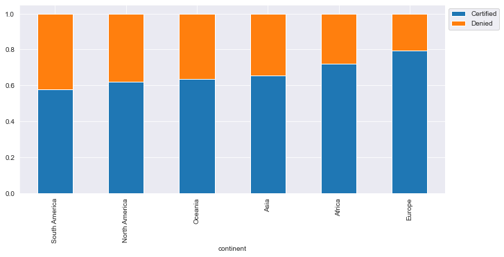

```python
# case_status vs continent stacked barplot
stacked_barplot(df1, "continent", "case_status")
```

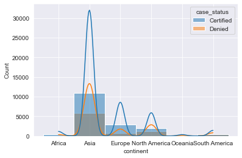

```python
# case_status vs continent distribution plot
sns.histplot(df1, x = "continent", hue = "case_status", kde = True)
```

### Observations for case_status vs continent

```
case_status            Certified  Denied    All
education_of_employee
All                        17018    8462  25480
Bachelor's                  6367    3867  10234
High School                 1164    2256   3420
Master's                    7575    2059   9634
Doctorate                   1912     280   2192
------------------------------------------------------------------------------------------------------------------------
```

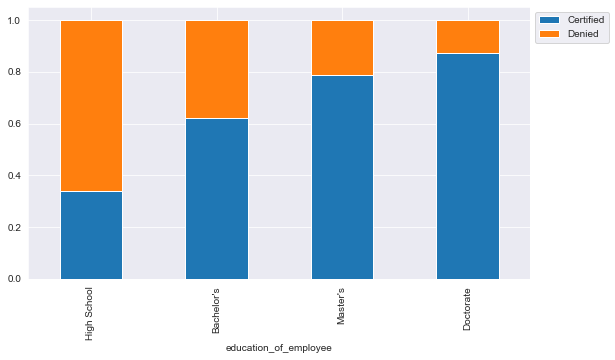

```python
# case_status vs education_of_employee stacked barplot
stacked_barplot(df1, "education_of_employee", "case_status")
```

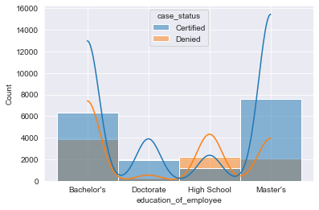

```python
# case_status vs education_of_employee distribution plot
sns.histplot(df1, x = "education_of_employee", hue = "case_status", kde = True)
```

### Observations for case_status vs education_of_employee

- Per the stacked barplot, Doctorate (approx 87%), Master's (approx 79%), Bachelor's (approx 62%), and High School (approx 35%) visas with those education levels were certified.
- Per the distribution plot, most of the applications were for Bachelor's and Master's degree (~79% for both education types) educated employees.

```
case_status         Certified  Denied    All
has_job_experience
All                     17018    8462  25480
N                        5994    4684  10678
Y                       11024    3778  14802
------------------------------------------------------------------------------------------------------------------------
```

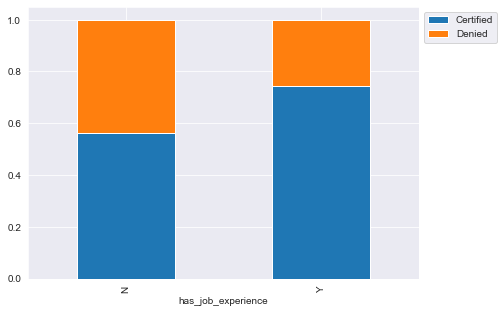

```python
# case_status vs has_job_experience stacked barplot
stacked_barplot(df1, "has_job_experience", "case_status")
```

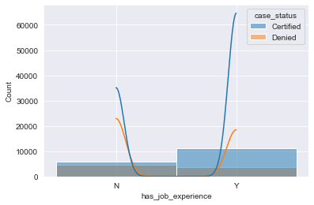

```python
# case_status vs has_job_experience distribution plot
sns.histplot(df1, x = "has_job_experience", hue = "case_status", kde = True)
```

```
case_status            Certified  Denied    All
requires_job_training
All                        17018    8462  25480
N                          15012    7513  22525
Y                           2006     949   2955
------------------------------------------------------------------------------------------------------------------------
```

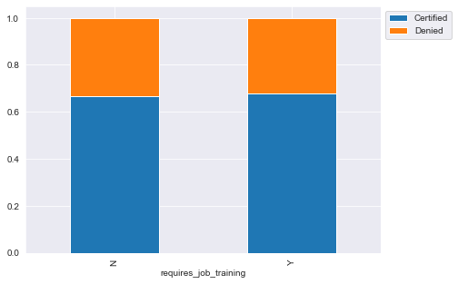

```python
# case_status vs requires_job_training stacked barplot
stacked_barplot(df1, "requires_job_training", "case_status")
```

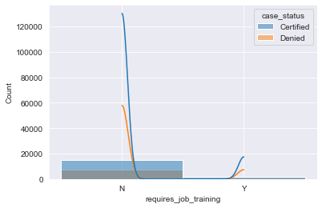

```python
# case_status vs requires_job_training distribution plot
sns.histplot(df1, x = "requires_job_training", hue = "case_status", kde = True)
```